# Medical Appointment Dataset

## In this we will be analyzing this dataset to answer a some qustions about people who miss thier oppinmemnt:

- Is there a relationship between age and not showing up
- Do alcholic people tend to miss their doctor appointments
- Do uneducated people tend to miss doctor appointments
- Is there a relationship between gender type and missing an appointment
- Is sending SMS help to remind Patients and keep their appointments

### First we will load all neede Libraries

```python
import pandas as pd
import numpy as np
import matplotlib.pyplot as plt
import seaborn as sns
%matplotlib inline
```

### Load the Dataset

```python
# Load the dataset
df = pd.read_csv('noshowappointments-kagglev2-may-2016 (1).csv')
```

### Basic info about the Dataset

```python
df.info()
```

```
<class 'pandas.core.frame.DataFrame'>
RangeIndex: 110527 entries, 0 to 110526
Data columns (total 14 columns):
 #   Column          Non-Null Count   Dtype
---  ------          --------------   -----
 0   PatientId       110527 non-null  float64
 1   AppointmentID   110527 non-null  int64
 2   Gender          110527 non-null  object
 3   ScheduledDay    110527 non-null  object
 4   AppointmentDay  110527 non-null  object
 5   Age             110527 non-null  int64
 6   Neighbourhood   110527 non-null  object
 7   Scholarship     110527 non-null  int64
 8   Hipertension    110527 non-null  int64
 9   Diabetes        110527 non-null  int64
 10  Alcoholism      110527 non-null  int64
 11  Handcap         110527 non-null  int64
 12  SMS_received    110527 non-null  int64
 13  No-show         110527 non-null  object
dtypes: float64(1), int64(8), object(5)
memory usage: 11.8+ MB
```

```python
df.shape
```

```
(110527, 14)
```

### As we can see we have 14 columns and 110527 records

```python
df.head()
```

|  | PatientId | AppointmentID | Gender | ScheduledDay | AppointmentDay | Age | Neighbourhood | Scholarship | Hipertension | Diabetes | Alcoholism | Handcap | SMS_received | No-show |
| --- | --- | --- | --- | --- | --- | --- | --- | --- | --- | --- | --- | --- | --- | --- |
| 0 | 2.987250e+13 | 5642903 | F | 2016-04-29T18:38:08Z | 2016-04-29T00:00:00Z | 62 | JARDIM DA PENHA | 0 | 1 | 0 | 0 | 0 | 0 | No |
| 1 | 5.589978e+14 | 5642503 | M | 2016-04-29T16:08:27Z | 2016-04-29T00:00:00Z | 56 | JARDIM DA PENHA | 0 | 0 | 0 | 0 | 0 | 0 | No |
| 2 | 4.262962e+12 | 5642549 | F | 2016-04-29T16:19:04Z | 2016-04-29T00:00:00Z | 62 | MATA DA PRAIA | 0 | 0 | 0 | 0 | 0 | 0 | No |
| 3 | 8.679512e+11 | 5642828 | F | 2016-04-29T17:29:31Z | 2016-04-29T00:00:00Z | 8 | PONTAL DE CAMBURI | 0 | 0 | 0 | 0 | 0 | 0 | No |
| 4 | 8.841186e+12 | 5642494 | F | 2016-04-29T16:07:23Z | 2016-04-29T00:00:00Z | 56 | JARDIM DA PENHA | 0 | 1 | 1 | 0 | 0 | 0 | No |

## corrections must to do in data type and typo

```python
# converts needed columns
df['PatientId']=df['PatientId'].astype('int64')
df['ScheduledDay']=pd.to_datetime(df['ScheduledDay'])
df['AppointmentDay']=pd.to_datetime(df['AppointmentDay'])
df['Scholarship'] = df['Scholarship'].astype('bool')
df['Hipertension'] = df['Hipertension'].astype('bool')
df['Diabetes'] = df['Diabetes'].astype('bool')
df['Alcoholism'] = df['Alcoholism'].astype('bool')
df['SMS_received'] = df['SMS_received'].astype('bool')
```

```python
# Rename columns
df= df.rename(columns={'Hipertension': 'Hypertension', 'Handcap': 'Handicap', 'SMS_received': 'SMSReceived', 'No-show': 'No_Show'})
```

```python
# check for converts
df.info()
```

```
<class 'pandas.core.frame.DataFrame'>
RangeIndex: 110527 entries, 0 to 110526
Data columns (total 14 columns):
 #   Column          Non-Null Count   Dtype
---  ------          --------------   -----
 0   PatientId       110527 non-null  int64
 1   AppointmentID   110527 non-null  int64
 2   Gender          110527 non-null  object
 3   ScheduledDay    110527 non-null  datetime64[ns, UTC]
 4   AppointmentDay  110527 non-null  datetime64[ns, UTC]
 5   Age             110527 non-null  int64
 6   Neighbourhood   110527 non-null  object
 7   Scholarship     110527 non-null  bool
 8   Hypertension    110527 non-null  bool
 9   Diabetes        110527 non-null  bool
 10  Alcoholism      110527 non-null  bool
 11  Handicap        110527 non-null  int64
 12  SMSReceived     110527 non-null  bool
 13  No_Show         110527 non-null  object
dtypes: bool(5), datetime64[ns, UTC](2), int64(4), object(3)
memory usage: 8.1+ MB
```

### Check duplicates and NaN values

```python
# check rename result
df.head()
```

|  | PatientId | AppointmentID | Gender | ScheduledDay | AppointmentDay | Age | Neighbourhood | Scholarship | Hypertension | Diabetes | Alcoholism | Handicap | SMSReceived | No_Show |
| --- | --- | --- | --- | --- | --- | --- | --- | --- | --- | --- | --- | --- | --- | --- |
| 0 | 29872499824296 | 5642903 | F | 2016-04-29 18:38:08+00:00 | 2016-04-29 00:00:00+00:00 | 62 | JARDIM DA PENHA | False | True | False | False | 0 | False | No |
| 1 | 558997776694438 | 5642503 | M | 2016-04-29 16:08:27+00:00 | 2016-04-29 00:00:00+00:00 | 56 | JARDIM DA PENHA | False | False | False | False | 0 | False | No |
| 2 | 4262962299951 | 5642549 | F | 2016-04-29 16:19:04+00:00 | 2016-04-29 00:00:00+00:00 | 62 | MATA DA PRAIA | False | False | False | False | 0 | False | No |
| 3 | 867951213174 | 5642828 | F | 2016-04-29 17:29:31+00:00 | 2016-04-29 00:00:00+00:00 | 8 | PONTAL DE CAMBURI | False | False | False | False | 0 | False | No |
| 4 | 8841186448183 | 5642494 | F | 2016-04-29 16:07:23+00:00 | 2016-04-29 00:00:00+00:00 | 56 | JARDIM DA PENHA | False | True | True | False | 0 | False | No |

```python
## check for duplicates
df.duplicated().sum()
```

```
0
```

```python
# check for null values
df.isnull().sum()
```

```
PatientId         0
AppointmentID     0
Gender            0
ScheduledDay      0
AppointmentDay    0
Age               0
Neighbourhood     0
Scholarship       0
Hypertension      0
Diabetes          0
Alcoholism        0
Handicap          0
SMSReceived       0
No_Show           0
dtype: int64
```

```python
## As PatientId and AppointmentID are system generates and no need for them we will drop it
df.drop(['PatientId','AppointmentID'], axis=1, inplace=True)
```

```python
### show unique values
print(df['Gender'].unique().tolist())
print(df['SMSReceived'].unique().tolist())
print(df.Handicap.unique())
print(df.Alcoholism.unique())
print(df.Diabetes.unique())
print(df.Hypertension.unique().tolist())
print(np.sort(df.Age.unique()))
```

```
['F', 'M']
[False, True]
[0 1 2 3 4]
[False  True]
[False  True]
[True, False]
[ -1   0   1   2   3   4   5   6   7   8   9  10  11  12  13  14  15  16
  17  18  19  20  21  22  23  24  25  26  27  28  29  30  31  32  33  34
  35  36  37  38  39  40  41  42  43  44  45  46  47  48  49  50  51  52
  53  54  55  56  57  58  59  60  61  62  63  64  65  66  67  68  69  70
  71  72  73  74  75  76  77  78  79  80  81  82  83  84  85  86  87  88
  89  90  91  92  93  94  95  96  97  98  99 100 102 115]
```

```python
df.Age.describe()
```

```
count    110527.000000
mean         37.088874
std          23.110205
min          -1.000000
25%          18.000000
50%          37.000000
75%          55.000000
max         115.000000
Name: Age, dtype: float64
```

```python
## As we see here Age has a -1 which is need to investigate
df[df.Age < 0]
```

|  | Gender | ScheduledDay | AppointmentDay | Age | Neighbourhood | Scholarship | Hypertension | Diabetes | Alcoholism | Handicap | SMSReceived | No_Show |
| --- | --- | --- | --- | --- | --- | --- | --- | --- | --- | --- | --- | --- |
| 99832 | F | 2016-06-06 08:58:13+00:00 | 2016-06-06 00:00:00+00:00 | -1 | ROMÃO | False | False | False | False | 0 | False | No |

```python
## As we notice here patinet with zero age could be babies Usually babies doesn't have Hypertension or Diabetes or Alcoholism we will check these features
df[(df.Age ==0) & ((df.Hypertension == 1)| (df.Diabetes == 1) | (df.Alcoholism == 1))]
```

|  | Gender | ScheduledDay | AppointmentDay | Age | Neighbourhood | Scholarship | Hypertension | Diabetes | Alcoholism | Handicap | SMSReceived | No_Show |
| --- | --- | --- | --- | --- | --- | --- | --- | --- | --- | --- | --- | --- |

```python
## drop the ages less than zero
indexAges = df[ df['Age'] < 0 ].index
df.drop(indexAges,inplace=True)
```

```python
### check result
df.query('Age < 0')
```

|  | Gender | ScheduledDay | AppointmentDay | Age | Neighbourhood | Scholarship | Hypertension | Diabetes | Alcoholism | Handicap | SMSReceived | No_Show |
| --- | --- | --- | --- | --- | --- | --- | --- | --- | --- | --- | --- | --- |

```python
# Since there are 27426 records for patient who are older than 55, I would like to make a closer look for people with age greater than 99.
df.loc[df['Age'] > 99]
```

|  | Gender | ScheduledDay | AppointmentDay | Age | Neighbourhood | Scholarship | Hypertension | Diabetes | Alcoholism | Handicap | SMSReceived | No_Show |
| --- | --- | --- | --- | --- | --- | --- | --- | --- | --- | --- | --- | --- |
| 58014 | F | 2016-05-03 09:14:53+00:00 | 2016-05-03 00:00:00+00:00 | 102 | CONQUISTA | False | False | False | False | 0 | False | No |
| 63912 | F | 2016-05-16 09:17:44+00:00 | 2016-05-19 00:00:00+00:00 | 115 | ANDORINHAS | False | False | False | False | 1 | False | Yes |
| 63915 | F | 2016-05-16 09:17:44+00:00 | 2016-05-19 00:00:00+00:00 | 115 | ANDORINHAS | False | False | False | False | 1 | False | Yes |
| 68127 | F | 2016-04-08 14:29:17+00:00 | 2016-05-16 00:00:00+00:00 | 115 | ANDORINHAS | False | False | False | False | 1 | False | Yes |
| 76284 | F | 2016-05-30 09:44:51+00:00 | 2016-05-30 00:00:00+00:00 | 115 | ANDORINHAS | False | False | False | False | 1 | False | No |
| 79270 | M | 2016-05-30 16:21:56+00:00 | 2016-05-31 00:00:00+00:00 | 100 | TABUAZEIRO | False | False | False | False | 1 | False | No |
| 79272 | M | 2016-05-30 16:21:56+00:00 | 2016-05-31 00:00:00+00:00 | 100 | TABUAZEIRO | False | False | False | False | 1 | False | No |
| 90372 | F | 2016-05-31 10:19:49+00:00 | 2016-06-02 00:00:00+00:00 | 102 | MARIA ORTIZ | False | False | False | False | 0 | False | No |
| 92084 | F | 2016-05-06 14:55:36+00:00 | 2016-06-03 00:00:00+00:00 | 100 | ANTÔNIO HONÓRIO | False | False | False | False | 0 | True | No |
| 97666 | F | 2016-05-19 07:57:56+00:00 | 2016-06-03 00:00:00+00:00 | 115 | SÃO JOSÉ | False | True | False | False | 0 | True | No |
| 108506 | F | 2016-05-19 15:32:09+00:00 | 2016-06-01 00:00:00+00:00 | 100 | MARUÍPE | False | False | False | False | 0 | False | No |

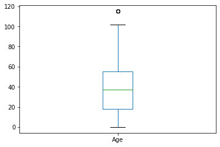

```python
# there are only 11 records for patients who are older than 99, but in fact there are only two patients who are 115 years old.
# We can also plot the box plot to see if the 115 is an outlier
df['Age'].plot(kind='box')
```

```python
# Notice that the 115 is represented as an outlier( a circle at the top).
# To drop all the rows with Age value is greater than 110
indexage1 = df[ df['Age']>110 ].index
# Delete these row indexes from dataFrame
df.drop(indexage1 , inplace=True)
```

```python
df.Age.describe()
```

```
count    110521.000000
mean         37.085694
std          23.104606
min           0.000000
25%          18.000000
50%          37.000000
75%          55.000000
max         102.000000
Name: Age, dtype: float64
```

```python
# Note that we have five different values for the Handcap variable. So we need to investegate these values.
df['Handicap'].value_counts(dropna=False)
```

```
0    108284
1      2038
2       183
3        13
4         3
Name: Handicap, dtype: int64
```

### The Frequency of values 2,3 and 4 is 199 which is a minority in comparisson with the 110527 entries. So I would consider them as typos and I will drop

```python
#To drop all the rows with Handicap value is greater than 1
indexhandicap = df[ df['Handicap']>1 ].index
# Delete these row indexes from dataFrame
df.drop(indexhandicap , inplace=True)
```

```python
#  Check out the changes
df['Handicap'].value_counts(dropna=False)
```

```
0    108284
1      2038
Name: Handicap, dtype: int64
```

```python
# correct data type for the Handicap column
df['Handicap'] = df['Handicap'].astype('bool')
```